```python
import numpy as np
import pandas as pd
from sklearn.ensemble import ExtraTreesClassifier
from sklearn.linear_model import LogisticRegression
from sklearn import metrics
from sklearn.model_selection import train_test_split
from sklearn.model_selection import StratifiedKFold
import seaborn as sns
import scipy.stats as stats
from sklearn.preprocessing import LabelEncoder
from sklearn.preprocessing import OrdinalEncoder
from sklearn.metrics import accuracy_score
```

# Introduction

## Strokes happen when something "blocks blood supply to part of the brain or when a blood vessel in the brain bursts."(About Stroke | cdc.gov, 2022). In America, strokes are the fifth leading cause of death and the leading cause of long-term disability.(Neurosciences - Stroke Facts, n.d.). For reference, for every 40 seconds in America someone has a stroke and for every 3.5 minutes, someone dies of a stroke.(Neurosciences - Stroke Facts, n.d.). This research will provide insight on the predictors of a patient having a stroke.

## The Stroke Prediction Dataset was obtained from Kaggle and contains the following variables.

## (Stroke Prediction Dataset, 2021)

## * id: unique identifier

## * gender: "Male", "Female" or "Other"

## * age: age of the patient

## * hypertension: 0 if the patient doesn't have hypertension, 1 if the patient has hypertension

## * heart_disease: 0 if the patient doesn't have any heart diseases, 1 if the patient has a heart disease

## * ever_married: "No" or "Yes"

## * work_type: "children", "Govt_jov", "Never_worked", "Private" or "Self-employed"

## * Residence_type: "Rural" or "Urban"

## * avg_glucose_level: average glucose level in blood

## * bmi: body mass index

## *smoking_status: "formerly smoked", "never smoked", "smokes" or "Unknown"*

## * stroke: 1 if the patient had a stroke or 0 if not

# Data Cleaning/Preprocessing

## To gain an understanding of the variables, the response variable 'stroke' and explantory variables 'hypertension' and 'heart disease' were transformed into categorical values.

```python
data = pd.read_csv("stroke.csv")
data_df = pd.DataFrame(data)
output_str = list()
output_hyp = list()
output_hrt = list()

for i,j in data_df['stroke'].iteritems():
  if (j == 1):
    output_str.append('Yes')
  elif (j == 0):
    output_str.append('No')
data_df['stroke'] = output_str

for i,j in data_df['hypertension'].iteritems():
  if (j == 1):
    output_hyp.append('Yes')
  elif (j == 0):
    output_hyp.append('No')
data_df['hypertension'] = output_hyp

for i,j in data_df['heart_disease'].iteritems():
  if (j == 1):
    output_hrt.append('Yes')
  elif (j == 0):
    output_hrt.append('No')
data_df['heart_disease'] = output_hrt
```

```python
data_df
```

|  | id | gender | age | hypertension | heart_disease | ever_married | work_type | Residence_type | avg_glucose_level | bmi | smoking_status | stroke |
| --- | --- | --- | --- | --- | --- | --- | --- | --- | --- | --- | --- | --- |
| 0 | 9046 | Male | 67.0 | No | Yes | Yes | Private | Urban | 228.69 | 36.6 | formerly smoked | Yes |
| 1 | 51676 | Female | 61.0 | No | No | Yes | Self-employed | Rural | 202.21 | NaN | never smoked | Yes |
| 2 | 31112 | Male | 80.0 | No | Yes | Yes | Private | Rural | 105.92 | 32.5 | never smoked | Yes |
| 3 | 60182 | Female | 49.0 | No | No | Yes | Private | Urban | 171.23 | 34.4 | smokes | Yes |
| 4 | 1665 | Female | 79.0 | Yes | No | Yes | Self-employed | Rural | 174.12 | 24.0 | never smoked | Yes |
| ... | ... | ... | ... | ... | ... | ... | ... | ... | ... | ... | ... | ... |
| 5105 | 18234 | Female | 80.0 | Yes | No | Yes | Private | Urban | 83.75 | NaN | never smoked | No |
| 5106 | 44873 | Female | 81.0 | No | No | Yes | Self-employed | Urban | 125.20 | 40.0 | never smoked | No |
| 5107 | 19723 | Female | 35.0 | No | No | Yes | Self-employed | Rural | 82.99 | 30.6 | never smoked | No |
| 5108 | 37544 | Male | 51.0 | No | No | Yes | Private | Rural | 166.29 | 25.6 | formerly smoked | No |
| 5109 | 44679 | Female | 44.0 | No | No | Yes | Govt_job | Urban | 85.28 | 26.2 | Unknown | No |

5110 rows × 12 columns

## The dataset contains over 5000 observation and also 201 missing values. Since the dataset is so large, the observations with missing values are negligble and will be dropped from the dataset.

```python
data_df.isna().sum()
```

```
id                     0
gender                 0
age                    0
hypertension           0
heart_disease          0
ever_married           0
work_type              0
Residence_type         0
avg_glucose_level      0
bmi                  201
smoking_status         0
stroke                 0
dtype: int64
```

```python
stroke_df = data_df.dropna()
stroke_df = pd.DataFrame(stroke_df)
```

```python
stroke_df
```

|  | id | gender | age | hypertension | heart_disease | ever_married | work_type | Residence_type | avg_glucose_level | bmi | smoking_status | stroke |
| --- | --- | --- | --- | --- | --- | --- | --- | --- | --- | --- | --- | --- |
| 0 | 9046 | Male | 67.0 | No | Yes | Yes | Private | Urban | 228.69 | 36.6 | formerly smoked | Yes |
| 2 | 31112 | Male | 80.0 | No | Yes | Yes | Private | Rural | 105.92 | 32.5 | never smoked | Yes |
| 3 | 60182 | Female | 49.0 | No | No | Yes | Private | Urban | 171.23 | 34.4 | smokes | Yes |
| 4 | 1665 | Female | 79.0 | Yes | No | Yes | Self-employed | Rural | 174.12 | 24.0 | never smoked | Yes |
| 5 | 56669 | Male | 81.0 | No | No | Yes | Private | Urban | 186.21 | 29.0 | formerly smoked | Yes |
| ... | ... | ... | ... | ... | ... | ... | ... | ... | ... | ... | ... | ... |
| 5104 | 14180 | Female | 13.0 | No | No | No | children | Rural | 103.08 | 18.6 | Unknown | No |
| 5106 | 44873 | Female | 81.0 | No | No | Yes | Self-employed | Urban | 125.20 | 40.0 | never smoked | No |
| 5107 | 19723 | Female | 35.0 | No | No | Yes | Self-employed | Rural | 82.99 | 30.6 | never smoked | No |
| 5108 | 37544 | Male | 51.0 | No | No | Yes | Private | Rural | 166.29 | 25.6 | formerly smoked | No |
| 5109 | 44679 | Female | 44.0 | No | No | Yes | Govt_job | Urban | 85.28 | 26.2 | Unknown | No |

4909 rows × 12 columns

## The patient 'id' is not useful in predicting the likelihood of a stroke and will also be removed from the dataset.

```python
stroke_df = stroke_df.drop(labels = 'id', axis=1)
```

## 30% of the obeservations contain a smoking status of 'Unknown'. Given that it is a large part of the data, the 'smoking_stauts' will not be used, because it is an unreliable metric

```python
(stroke_df.iloc[:,9:10] == 'Unknown').sum()
```

```
smoking_status    1483
dtype: int64
```

```python
stroke_df = stroke_df.drop(labels = 'smoking_status', axis=1)
```

```python
stroke_df
```

|  | gender | age | hypertension | heart_disease | ever_married | work_type | Residence_type | avg_glucose_level | bmi | stroke |
| --- | --- | --- | --- | --- | --- | --- | --- | --- | --- | --- |
| 0 | Male | 67.0 | No | Yes | Yes | Private | Urban | 228.69 | 36.6 | Yes |
| 2 | Male | 80.0 | No | Yes | Yes | Private | Rural | 105.92 | 32.5 | Yes |
| 3 | Female | 49.0 | No | No | Yes | Private | Urban | 171.23 | 34.4 | Yes |
| 4 | Female | 79.0 | Yes | No | Yes | Self-employed | Rural | 174.12 | 24.0 | Yes |
| 5 | Male | 81.0 | No | No | Yes | Private | Urban | 186.21 | 29.0 | Yes |
| ... | ... | ... | ... | ... | ... | ... | ... | ... | ... | ... |
| 5104 | Female | 13.0 | No | No | No | children | Rural | 103.08 | 18.6 | No |
| 5106 | Female | 81.0 | No | No | Yes | Self-employed | Urban | 125.20 | 40.0 | No |
| 5107 | Female | 35.0 | No | No | Yes | Self-employed | Rural | 82.99 | 30.6 | No |
| 5108 | Male | 51.0 | No | No | Yes | Private | Rural | 166.29 | 25.6 | No |
| 5109 | Female | 44.0 | No | No | Yes | Govt_job | Urban | 85.28 | 26.2 | No |

4909 rows × 10 columns

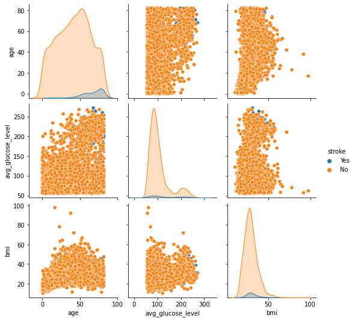

```python
sns.pairplot(stroke_df, hue='stroke')
```

## Upon analyzing the current results, it is seent that 95% of the data hold a stroke indicator of 'No'. Due the the bias/variance tradeoff, the predicted results may hold bias to the initial results within the initial dataset.

```python
stroke_df['stroke'].value_counts(normalize=True)
```

```
No     0.957425
Yes    0.042575
Name: stroke, dtype: float64
```

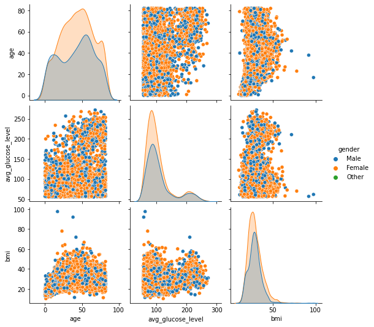

```python
sns.pairplot(stroke_df, hue='gender')
```

## It can also be observed that the data contains a majority female patients.

```python
stroke_df.describe().transpose()
```

|  | count | mean | std | min | 25% | 50% | 75% | max |
| --- | --- | --- | --- | --- | --- | --- | --- | --- |
| age | 4909.0 | 42.865374 | 22.555115 | 0.08 | 25.00 | 44.00 | 60.00 | 82.00 |
| avg_glucose_level | 4909.0 | 105.305150 | 44.424341 | 55.12 | 77.07 | 91.68 | 113.57 | 271.74 |
| bmi | 4909.0 | 28.893237 | 7.854067 | 10.30 | 23.50 | 28.10 | 33.10 | 97.60 |

The model was created using a randomized 80/20 split.

```python
# set seed
np.random.seed(1234)
data_randomized = stroke_df.sample(frac=0.8)
```

## The dataset consists of several categorical variables that need to be encoded. An ordinal encoder will be used on the explanatory variables because of its (categories , n_features) structure. The label encoder will be used on the explanatory variable because it only takes in one arrary containing categorical values.

```python
le = LabelEncoder()
enc = OrdinalEncoder()
```

```python
data_randomized
```

|  | gender | age | hypertension | heart_disease | ever_married | work_type | Residence_type | avg_glucose_level | bmi | stroke |
| --- | --- | --- | --- | --- | --- | --- | --- | --- | --- | --- |
| 4752 | Female | 16.0 | No | No | No | Private | Rural | 87.54 | 37.8 | No |
| 2586 | Female | 22.0 | No | No | No | Govt_job | Urban | 123.23 | 21.3 | No |
| 434 | Male | 64.0 | No | No | Yes | Govt_job | Urban | 94.48 | 31.1 | No |
| 2278 | Male | 42.0 | No | No | Yes | Private | Rural | 145.50 | 31.8 | No |
| 2873 | Female | 40.0 | No | No | Yes | Private | Rural | 83.30 | 32.0 | No |
| ... | ... | ... | ... | ... | ... | ... | ... | ... | ... | ... |
| 317 | Female | 37.0 | Yes | No | Yes | Self-employed | Rural | 127.71 | 36.0 | No |
| 4586 | Female | 53.0 | No | No | Yes | Private | Urban | 85.46 | 30.0 | No |
| 1024 | Male | 39.0 | No | No | Yes | Private | Urban | 95.44 | 38.4 | No |
| 1307 | Female | 25.0 | No | No | No | Private | Rural | 92.82 | 24.1 | No |
| 1929 | Male | 9.0 | No | No | No | children | Rural | 65.52 | 33.5 | No |

3927 rows × 10 columns

## The column names are taken from the new dataframe for later.

```python
colnames = data_randomized.iloc[:,:-1].columns
```

# Logistic Regression with Cross Validation

## Logistic regression is a statistical model used for classification and predictive analytics. It "estimates the probability of an event occurring, such as voted or didn’t vote, based on a given dataset of independent variables. Since the outcome is a probability, the dependent variable is bounded between 0 and 1." (What Is Logistic Regression? | IBM, n.d.)

## Since the model predicts the output based on 0 and 1 (or yes and no for our case), we use our label encoder to transform our response variable 'stroke' from "Yes" and "No', to "1" and "0" respectively.

## "Cross validation (CV) is one of the technique used to test the effectiveness of a machine learning models, it is also a re-sampling procedure used to evaluate a model if we have a limited data." (.M, 2020)

## A stratified sample will "divide a population into homogeneous subpopulations called strata (the plural of stratum) based on specific characteristics (e.g., race, gender identity, location, etc.). Every member of the population studied should be in exactly one stratum. Each stratum is then sampled using another probability sampling method, such as cluster or simple random sampling, allowing researchers to estimate statistical measures for each sub-population. Researchers rely on stratified sampling when a population’s characteristics are diverse and they want to ensure that every characteristic is properly represented in the sample." (Thomas, 2022)

## To verify the accuracy of the model, a stratified k-fold is used to split the randomized data into training and testing datasets.

```python
# Creating our training and sample data
np.random.seed(123)
skf = StratifiedKFold(n_splits= 5, shuffle= True)
err = []
model_one = LogisticRegression(max_iter=600)
for tr_index, te_index in skf.split(data_randomized, data_randomized['stroke']):
    x_train = data_randomized.iloc[tr_index]
    x_train =  x_train.iloc[:,:-1]
    x_train = enc.fit_transform(x_train)
    x_train = pd.DataFrame(x_train, columns=colnames)

    x_test = data_randomized.iloc[te_index]
    x_test =  x_test.iloc[:,:-1]
    x_test = enc.fit_transform(x_test)
    x_test = pd.DataFrame(x_test, columns=colnames)

    y_train = data_randomized['stroke'].iloc[tr_index]
    y_test = data_randomized['stroke'].iloc[te_index]

    y_train = le.fit_transform(y_train)
    y_test = le.fit_transform(y_test)

    model_one.fit(x_train,y_train)
    yhat_test_one = model_one.predict(x_test)

    err.append(metrics.accuracy_score(y_test,yhat_test_one))
```

# Logisitc Regression Results

## The average accuracy score is 95.75%

```python
print(f"Accuracy Score: {np.round((sum(err)/len(err)) * 100, 2)}%")
```

```
Accuracy Score: 95.75%
```

# Extra Tree Classifier with Cross Validation

## An Extra Tree Classifier is defined as "a type of ensemble learning technique which aggregates the results of multiple de-correlated decision trees collected in a “forest” to output it’s classification result." (GeeksforGeeks, 2020)

## "Each Decision Tree in the Extra Trees Forest is constructed from the original training sample. Then, at each test node, Each tree is provided with a random sample of k features from the feature-set from which each decision tree must select the best feature to split the data based on some mathematical criteria (typically the Gini Index). This random sample of features leads to the creation of multiple de-correlated decision trees."(GeeksforGeeks, 2020)

```python
# Creating our training and sample data
np.random.seed(123)
skf = StratifiedKFold(n_splits=5,shuffle = True)
tree_count = [500,1000,2000,3000,5000,7000]
err = []
out = list()
for tree in tree_count:
  model_two = ExtraTreesClassifier(n_estimators=tree)
  for tr_index, te_index in skf.split(data_randomized, data_randomized['stroke']):
    x_train = data_randomized.iloc[tr_index]
    x_train =  x_train.iloc[:,:-1]
    x_train = enc.fit_transform(x_train)
    x_train = pd.DataFrame(x_train, columns=colnames)

    x_test = data_randomized.iloc[te_index]
    x_test =  x_test.iloc[:,:-1]
    x_test = enc.fit_transform(x_test)
    x_test = pd.DataFrame(x_test, columns=colnames)

    y_train = data_randomized['stroke'].iloc[tr_index]
    y_test = data_randomized['stroke'].iloc[te_index]

    y_train = le.fit_transform(y_train)
    y_test = le.fit_transform(y_test)
    model_two.fit(x_train,y_train)
    yhat_test_two = model_two.predict(x_test)


    err.append(metrics.accuracy_score(y_test,yhat_test_two))
  out.append(f"Accuracy: {np.round((sum(err)/len(err)) * 100, 2)}% with {tree} trees")
```

# Extra Tree Classification Results

## The Extra Tree Classifier produced similar results across multiple tree sets. This means that our model is accurate when reproducing the predicted values. With the highest accuraccy score of 95.54% with 7000 trees

```python
for output in out:
  print(output)
```

```
Accuracy: 95.47% with 500 trees
Accuracy: 95.53% with 1000 trees
Accuracy: 95.52% with 2000 trees
Accuracy: 95.51% with 3000 trees
Accuracy: 95.52% with 5000 trees
Accuracy: 95.54% with 7000 trees
```

# Conclusion

## In conclusion, both classification models produced similar results on the smaller dataset. Given that logistic regression is divdies the predictors into two categories, while decision tress divides them into multiple boundaries, it is expected that logistic regression will work just as well on the smaller dataset. If however, we were to have a larger number of explanatory variables within the dataset, the extra tree classification model will out perform and produce more accurate results.

# References

3.3. Metrics and scoring: quantifying the quality of predictions. (n.d.). Scikit-learn. https://scikit-learn.org/stable/modules/model_evaluation.html

About Stroke | cdc.gov. (2022, November 2). Centers for Disease Control and Prevention. https://www.cdc.gov/stroke/about.htm GeeksforGeeks. (2020, July 2). ML | Extra Tree Classifier for Feature Selection. https://www.geeksforgeeks.org/ml-extra-tree-classifier-for-feature-selection/ Neurosciences - Stroke Facts. (n.d.). UTMBHealthCOM. https://www.utmbhealth.com/services/neurology/procedures-conditions/stroke/stroke-facts seaborn.pairplot — seaborn 0.12.1 documentation. (n.d.). https://seaborn.pydata.org/generated/seaborn.pairplot.html sklearn.ensemble.ExtraTreesClassifier. (n.d.). Scikit-learn. https://scikit-learn.org/stable/modules/generated/sklearn.ensemble.ExtraTreesClassifier.html sklearn.linear_model.LogisticRegression. (n.d.). Scikit-learn. https://scikit-learn.org/stable/modules/generated/sklearn.linear_model.LogisticRegression.html sklearn.model_selection.StratifiedKFold. (n.d.). Scikit-learn. https://scikit-learn.org/stable/modules/generated/sklearn.model_selection.StratifiedKFold.html sklearn.preprocessing.LabelEncoder. (n.d.). Scikit-learn. https://scikit-learn.org/stable/modules/generated/sklearn.preprocessing.LabelEncoder.html sklearn.preprocessing.OrdinalEncoder. (n.d.). Scikit-learn. https://scikit-learn.org/stable/modules/generated/sklearn.preprocessing.OrdinalEncoder.html Stroke Facts | cdc.gov. (2022, October 14). Centers for Disease Control and Prevention. https://www.cdc.gov/stroke/facts.html Stroke Prediction Dataset. (2021, January 26). Kaggle. https://www.kaggle.com/datasets/fedesoriano/stroke-prediction-dataset Thomas, L. (2022, July 21). Stratified Sampling | Definition, Guide & Examples. Scribbr. https://www.scribbr.com/methodology/stratified-sampling/ What is Logistic regression? | IBM. (n.d.). https://www.ibm.com/topics/logistic-regression